# Classification des consommateurs de saumon

## Importation des données et séparation des matrices

Le fichier contient deux types de lignes décrites sur les mêmes 30 produits. Les 1063 premières sont des consommateurs : leurs notes des produits forment X1 et leurs réponses au questionnaire forment X2. Les 25 dernières décrivent les produits (mesures physico-chimiques, microbiologiques, couleur et origine) et forment X3.

Chaque ligne de X1 et de X3 est centrée-réduite sur les 30 produits. Pour un consommateur, seul l’ordre de ses préférences compte, pas son niveau moyen de notation. Le consommateur 1003 n’a aucune note : on le retire, car l’imputer reviendrait à lui inventer des préférences.

```r
library(FactoMineR)

saumon <- read.csv2("saumon.csv", row.names = 1,
                    stringsAsFactors = TRUE, check.names = FALSE)

X1 <- droplevels(saumon[1:1063, 1:31])             # consommateurs x (Country + produits)
X2 <- droplevels(saumon[1:1063, 32:ncol(saumon)])  # consommateurs x questionnaire
X3 <- saumon[1064:nrow(saumon), 2:31]              # descripteurs x produits

# Un consommateur n'a aucune note : on le retire
ok <- rowSums(is.na(X1[, -1])) < 30
X1 <- X1[ok, ]
X2 <- X2[ok, ]
```

## ACP de X1 avec les variables de X2 en supplémentaire

Les individus sont les consommateurs et les variables actives sont les 30 produits. L’ACP est normée, chaque produit a donc le même poids. Deux consommateurs proches sur les axes classent les produits de façon semblable.

Country et les variables de X2 sont supplémentaires : elles ne participent pas à la construction des axes. Chaque modalité est placée au barycentre des consommateurs qui la possèdent. `dimdesc` teste le lien entre une variable et un axe (R² de l’analyse de variance des coordonnées). La v.test d’une modalité mesure l’écart de son barycentre à l’origine ; au-delà de 2 en valeur absolue, l’écart est significatif au seuil de 5 %.

On garde 10 axes pour la classification, ce qui écarte les dernières dimensions, surtout porteuses de bruit.

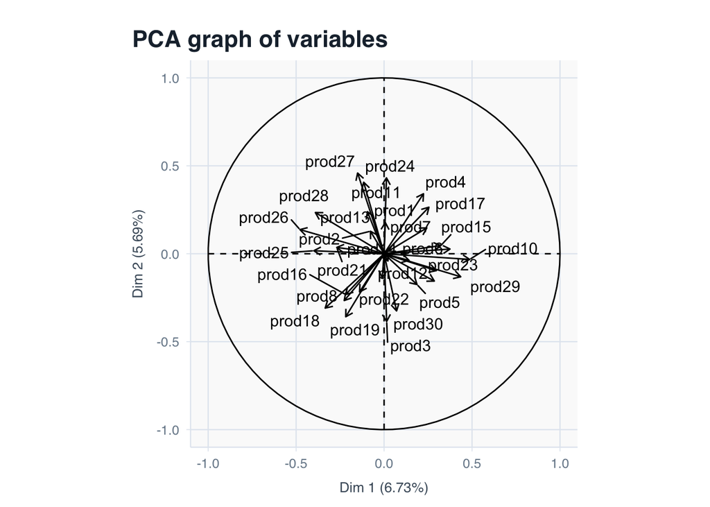

```r
set.seed(123)  # ncp < 15 : FactoMineR utilise une SVD approchée à départ aléatoire
res_pca <- PCA(cbind(X1, X2), quali.sup = c(1, 32:99), ncp = 10, graph = FALSE)

plot(res_pca, choix = "var")
```

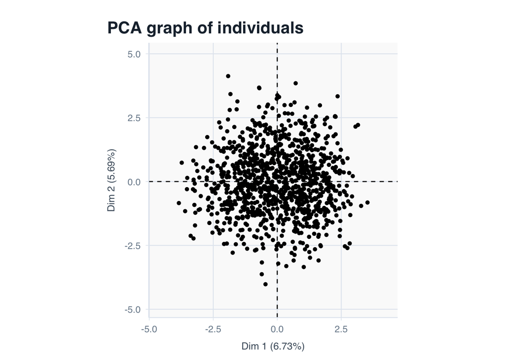

```r
plot(res_pca, choix = "ind", label = "none", invisible = "quali")
```

```r
# Variables de X2 liées aux axes 1 et 2
lapply(dimdesc(res_pca, axes = 1:2), function(d) d$quali)
```

```
## $Dim.1
##                               R2      p.value
## Not too salty        0.031880380 4.657657e-09
## Smooth texture       0.010994875 6.204533e-04
## Country              0.025737535 2.162877e-03
## Wild                 0.008021020 3.488525e-03
## Evening snack        0.007474091 4.812607e-03
## Firm texture         0.007028597 6.262780e-03
## Not expensive        0.012903633 8.169715e-03
## Characteristic taste 0.006554046 8.303260e-03
## Nice colour          0.004801835 2.392860e-02
## Number slices        0.004726374 2.506389e-02
## Horseradish          0.004232438 3.401827e-02
##
## $Dim.2
##                                  R2      p.value
## Country                 0.053436498 8.886214e-09
## Who                     0.018690174 4.585167e-05
## Not too salty           0.015129604 5.844672e-05
## Healthy                 0.021245052 1.440619e-04
## Starter                 0.011649931 4.257690e-04
## C. fraiche              0.011595268 4.393422e-04
## Use by date             0.008486019 2.656851e-03
## Scottish                0.007475598 4.808332e-03
## Wild                    0.007245877 5.506936e-03
## Supermarket             0.006846096 6.978929e-03
## Fish shop               0.006468768 8.736449e-03
## Lemon, bread, butter    0.006119526 1.076588e-02
## Appetising              0.005985449 1.166795e-02
## Fresh cheese            0.005496870 1.566582e-02
## C. fraiche with herbs   0.005149728 1.934302e-02
## Pleasure                0.010648553 2.312892e-02
## Authentic               0.009925548 3.206555e-02
## Do not know             0.003866043 4.278157e-02
## Butter                  0.003803289 4.450580e-02
## Deli                    0.003666975 4.850790e-02
## Fresh cheese with herbs 0.003656660 4.882577e-02
## Black pepper            0.003652647 4.895005e-02
##
## $call
## NULL
```

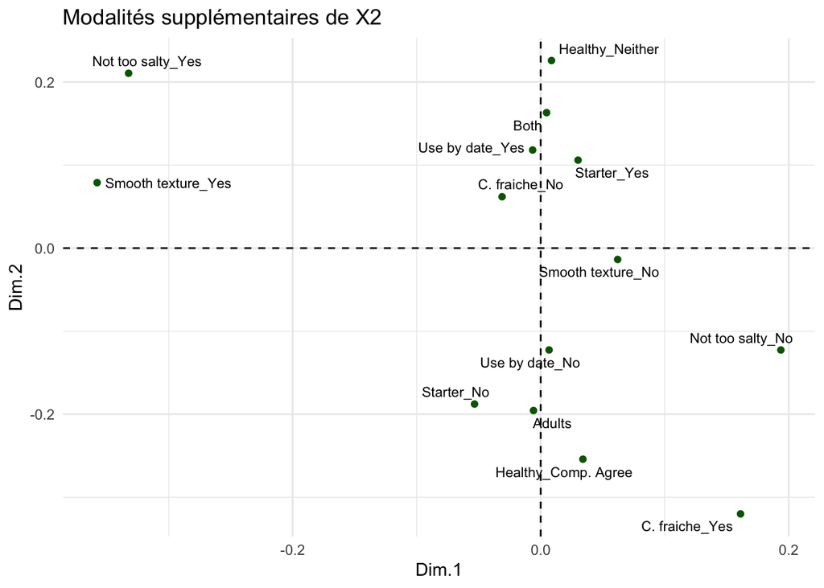

```r
# Modalités de X2 les plus liées aux axes 1 et 2 (|v.test| > 3)
library(ggplot2)
mod <- as.data.frame(res_pca$quali.sup$coord[, 1:2])
mod <- mod[-(1:nlevels(X1$Country)), ]
mod <- mod[apply(abs(res_pca$quali.sup$v.test[rownames(mod), 1:2]), 1, max) > 3, ]

ggplot(mod, aes(Dim.1, Dim.2, label = rownames(mod))) +
  geom_hline(yintercept = 0, linetype = 2) +
  geom_vline(xintercept = 0, linetype = 2) +
  geom_point(colour = "darkgreen") +
  ggrepel::geom_text_repel(size = 3) +
  labs(title = "Modalités supplémentaires de X2") +
  theme_minimal()
```

## Classification hiérarchique des consommateurs (k = 3)

On regroupe les consommateurs à partir de leurs coordonnées sur les 10 axes de l’ACP. La classification ascendante hiérarchique utilise le critère de Ward : à chaque étape, elle fusionne les deux classes dont la réunion fait le moins augmenter l’inertie intra-classe. On coupe l’arbre en 3 classes, puis une consolidation par k-means réaffecte chaque consommateur à la classe dont le centre est le plus proche.

X2 n’intervient pas dans la partition, il sert seulement à décrire les classes. `desc.var$quanti` donne les produits dont la note moyenne dans la classe s’écarte significativement de la moyenne générale (v.test). `desc.var$category` donne les modalités de X2 sur- ou sous-représentées dans chaque classe (test hypergéométrique).

```r
# Classification sur les 10 premiers axes de l'ACP
# Ward.D2 : minimise l'augmentation de l'inertie intra-classe
# nb.clust = 3 :  il y'a un saut important de l'inertie, on impose 3 classes
# consol = TRUE : consolidation par k-means
res_hcpc <- HCPC(res_pca, nb.clust = 3, consol = TRUE, graph = FALSE)

classe <- res_hcpc$data.clust$clust
table(classe)
```

```
## classe
##   1   2   3
## 388 330 344
```

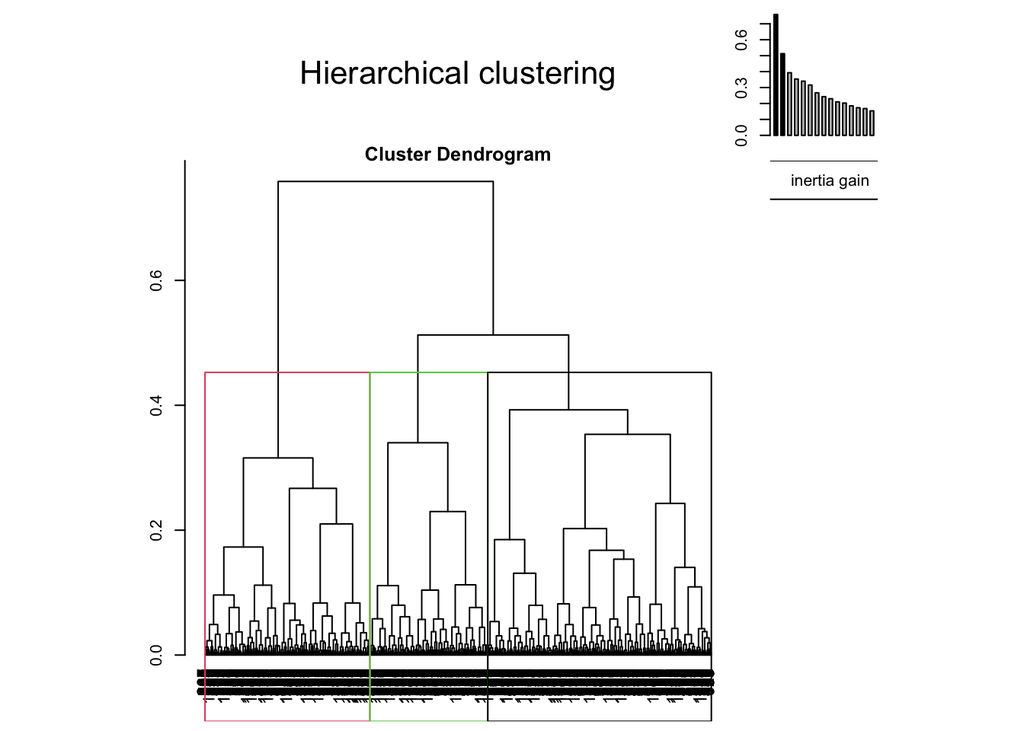

```r
plot(res_hcpc, choice = "tree")
```

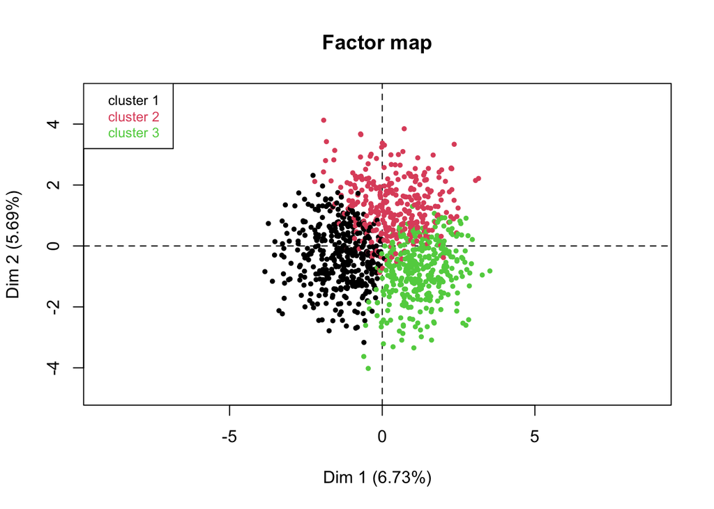

```r
plot(res_hcpc, choice = "map", draw.tree = FALSE, ind.names = FALSE)
```

```r
res_hcpc$desc.var$quanti
```

```
## $`1`
##            v.test Mean in category Overall mean sd in category Overall sd
## prod25  10.175277       0.21279613 -0.226143974      1.0119640  1.0661115
## prod26   9.172240       0.37203789  0.003308945      0.8706342  0.9935173
## prod16   9.020139       0.23823041 -0.146154331      0.9797317  1.0531653
## prod18   8.434931       0.25024124 -0.124637006      1.0528276  1.0983792
## prod21   7.939359      -0.14332088 -0.489062524      1.0414897  1.0762418
## prod8    7.706405       0.29503015 -0.024506026      0.9467613  1.0247355
## prod19   7.208734       0.24427345 -0.065253107      1.0042711  1.0611640
## prod28   6.656719       0.19076392 -0.087735782      0.9393555  1.0339704
## prod22   4.679766       0.45442268  0.279607439      0.8237799  0.9232064
## prod27   2.735317       0.25007758  0.145134557      0.8763096  0.9481771
## prod12   2.566946       0.12269691  0.019547834      1.0231848  0.9930981
## prod24  -2.009944      -0.24292706 -0.163490207      1.0067625  0.9767459
## prod5   -3.427382       0.15803531  0.286636911      0.9928069  0.9273154
## prod6   -4.362589      -0.02568170  0.130424576      0.9065686  0.8843407
## prod20  -5.025639      -0.44950258 -0.245391996      0.9973329  1.0037322
## prod9   -6.347262      -0.05990103  0.176899812      0.9514971  0.9220202
## prod23  -7.491547      -0.06928763  0.214053107      0.9505194  0.9347191
## prod4   -7.617681      -0.01287758  0.250802825      0.8616192  0.8554580
## prod15  -8.271571      -0.37221830 -0.035925330      1.0237082  1.0047856
## prod17  -8.924261      -0.12466443  0.204312524      0.9238850  0.9110387
## prod7   -9.088832      -0.52095155 -0.172825612      0.8845134  0.9466117
## prod29 -11.130913      -0.34822706  0.082470056      0.9152114  0.9562793
## prod10 -13.225465      -0.86928634 -0.339467326      0.8589528  0.9900570
##             p.value   n
## prod25 2.556713e-24 388
## prod26 4.632904e-20 388
## prod16 1.878513e-19 388
## prod18 3.313980e-17 388
## prod21 2.032289e-15 388
## prod8  1.294112e-14 388
## prod19 5.647432e-13 388
## prod28 2.800072e-11 388
## prod22 2.872029e-06 388
## prod27 6.232021e-03 388
## prod12 1.025985e-02 388
## prod24 4.443707e-02 388
## prod5  6.094313e-04 388
## prod6  1.285321e-05 388
```

[output cut: 92 more lines]

```
## prod30 1.069684e-07 344
## prod3  2.093595e-06 344
## prod5  5.237570e-06 344
## prod12 6.345124e-04 344
## prod14 1.118087e-03 344
## prod4  1.364783e-02 344
## prod18 1.009089e-02 344
## prod24 1.917904e-07 344
## prod13 1.994581e-08 344
## prod21 4.751849e-09 344
## prod11 1.544583e-11 344
## prod25 2.229179e-16 344
## prod28 2.493430e-24 344
## prod27 7.891531e-33 344
## prod26 3.214490e-35 344
```

```r
res_hcpc$desc.var$category
```

```
## $`1`
##                                          Cla/Mod    Mod/Cla    Global
## Not too salty=Not too salty_Yes         42.45524 42.7835052 36.817326
## Wild=Wild_Yes                           45.49763 24.7422680 19.868173
## Firm texture=Firm texture_No            38.62816 82.7319588 78.248588
## Horseradish=Horseradish_Yes             45.00000 20.8762887 16.949153
## Glossiness=Glossiness_Yes               42.43421 33.2474227 28.625235
## Smooth texture=Smooth texture_Yes       45.22293 18.2989691 14.783427
## Appetising=Appetising_Yes               40.29536 49.2268041 44.632768
## Advertising=Advertising_Yes             52.50000  5.4123711  3.766478
## Not expensive=Not expensive_Comp. Agree 51.16279  5.6701031  4.048964
## Lemon=Lemon_No                          38.90625 64.1752577 60.263653
## Lemon=Lemon_Yes                         32.93839 35.8247423 39.736347
## Pleasure=Pleasure_Comp. Disa.           12.50000  0.5154639  1.506591
## Advertising=Advertising_No              35.90998 94.5876289 96.233522
## Appetising=Appetising_No                33.50340 50.7731959 55.367232
## Smooth texture=Smooth texture_No        35.02762 81.7010309 85.216573
## Glossiness=Glossiness_No                34.16887 66.7525773 71.374765
## Horseradish=Horseradish_No              34.80726 79.1237113 83.050847
## Firm texture=Firm texture_Yes           29.00433 17.2680412 21.751412
## Wild=Wild_No                            34.31257 75.2577320 80.131827
## Not too salty=Not too salty_No          33.08495 57.2164948 63.182674
## Country=Nantes                          22.93578  6.4432990 10.263653
##                                             p.value    v.test
## Not too salty=Not too salty_Yes         0.002348239  3.042241
## Wild=Wild_Yes                           0.002848447  2.983637
## Firm texture=Firm texture_No            0.006762775  2.708305
## Horseradish=Horseradish_Yes             0.010582931  2.556177
## Glossiness=Glossiness_Yes               0.012065202  2.510232
## Smooth texture=Smooth texture_Yes       0.015650748  2.416960
## Appetising=Appetising_Yes               0.022680385  2.278776
## Advertising=Advertising_Yes             0.037745348  2.077609
## Not expensive=Not expensive_Comp. Agree 0.047624670  1.980702
## Lemon=Lemon_No                          0.048108897  1.976405
## Lemon=Lemon_Yes                         0.048108897 -1.976405
## Pleasure=Pleasure_Comp. Disa.           0.040385670 -2.049782
## Advertising=Advertising_No              0.037745348 -2.077609
## Appetising=Appetising_No                0.022680385 -2.278776
## Smooth texture=Smooth texture_No        0.015650748 -2.416960
## Glossiness=Glossiness_No                0.012065202 -2.510232
```

[output cut: 88 more lines]

```
## Healthy=Healthy_Comp. Agree                     2.908588e-03  2.977237
## Not expensive=Not expensive_Neither             5.014592e-03  2.806095
## Characteristic taste=Characteristic taste_Yes   1.080617e-02  2.548905
## Who=Adults                                      1.488055e-02  2.435273
## Labelling information=Labelling information_Yes 2.669970e-02  2.215880
## C. fraiche=C. fraiche_Yes                       3.108801e-02  2.155944
## Not expensive=Not expensive_Most. Disa.         3.825954e-02 -2.072063
## Country=F                                       3.809330e-02 -2.073849
## C. fraiche=C. fraiche_No                        3.108801e-02 -2.155944
## Authentic=Authentic_Most. Disa.                 2.794301e-02 -2.198086
## Labelling information=Labelling information_No  2.669970e-02 -2.215880
## Who=Both                                        1.673727e-02 -2.392429
## Characteristic taste=Characteristic taste_No    1.080617e-02 -2.548905
## Lemon, bread, butter=Lemon, bread, butter_Yes   2.895314e-03 -2.978639
## Not too salty=Not too salty_Yes                 4.817158e-05 -4.064325
```

## ACP des classes avec les descripteurs de X3 en supplémentaire

Chaque classe est résumée par son profil moyen, la note moyenne de ses consommateurs sur chaque produit. Ce profil est centré-réduit sur les 30 produits, comme les lignes de X3, pour que classes et descripteurs soient sur la même échelle.

Les 3 classes sont les individus actifs et les 30 produits les variables. L’ACP n’est pas normée : avec 3 individus, réduire chaque produit n’aurait pas de sens. Trois individus définissent un plan, donc les deux premiers axes portent toute l’inertie. Les 25 lignes de X3 sont projetées en individus supplémentaires.

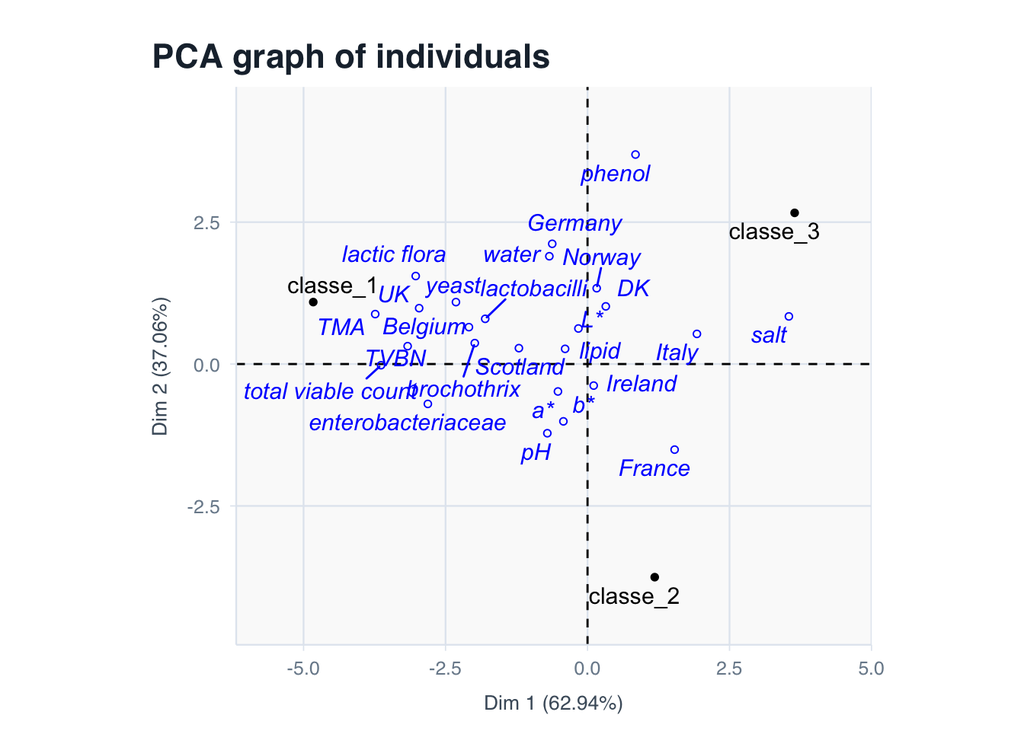

```r
# Profil moyen de chaque classe, centré-réduit sur les produits comme les lignes de X3
cr <- function(x) (x - mean(x)) / sqrt(mean((x - mean(x))^2))
profils <- t(sapply(split(X1[, -1], classe), colMeans))
profils <- t(apply(profils, 1, cr))
rownames(profils) <- paste0("classe_", rownames(profils))

don <- rbind(profils, X3)
res_pca_cl <- PCA(don, ind.sup = 4:nrow(don), scale.unit = FALSE, graph = FALSE)

plot(res_pca_cl, choix = "ind")
```

Une ligne de X3 se lit comme le profil d’un consommateur fictif dont la préférence suivrait exactement le descripteur. Pour la ligne `salt`, ce consommateur préférerait le produit le plus salé ; pour une ligne d’origine (0/1), il préférerait les produits de cette origine. Un descripteur proche d’une classe indique que ses consommateurs préfèrent les produits où ce descripteur est élevé. Cette lecture ne vaut que pour un descripteur bien représenté sur le plan (cos² élevé).

# Conclusion : Apport des variables x2 et x3

La comparaison des matrices X2 et X3 permet de compléter l’interprétation de la classification des consommateurs. Les variables de X2, correspondant aux réponses au questionnaire, permettent de caractériser les consommateurs selon leurs profils et leurs habitudes. Toutefois, les associations entre ces variables et les classes obtenues restent relativement faibles, ce qui suggère que les différences de préférences ne s’expliquent pas uniquement par les caractéristiques des consommateurs. En revanche, les descripteurs de X3 permettent de relier les classes aux caractéristiques des produits, notamment à des variables telles que la teneur en sel ou la fraîcheur. X3 apporte ainsi une interprétation plus directe des préférences des consommateurs en mettant en évidence les caractéristiques des saumons associées aux différents profils de préférence.